# Slooze_Challenge_Analysis_Tejaswini

Slooze Take-Home Challenge — Inventory, Purchase, and Sales Optimization

Objective: Analyze and optimize inventory management for a retail wine & spirits company operating across multiple locations.

## Project Overview

This notebook delivers a data-driven analysis of sales, purchases, and inventory records to extract actionable business insights and optimize stock management efficiency.  
The analysis leverages historical datasets to forecast demand, identify top-performing products, and refine supplier performance — enabling better decision-making for procurement and stocking.

### 1️⃣ Demand Forecasting

- Analyze historical sales data to predict future demand.
- Use time-series models or moving averages for trend estimation.

### 2️⃣ ABC Analysis

- Classify inventory into:
  - A — High-value items (top ~80% of revenue)
  - B — Moderate-value items
  - C — Low-priority items
- Prioritize A-class products for tighter control.

### 3️⃣ Economic Order Quantity (EOQ) Analysis

- Calculate the optimal order quantity (EOQ) that minimizes total cost (ordering + carrying).
- Use EOQ formula:  
  [ EOQ = \sqrt{\frac{2DS}{H}} ]  
  where  
  *D = annual demand, S = cost per order, H = holding cost per unit/year.*

### 4️⃣ Reorder Point (ROP) Analysis

- Determine reorder levels to prevent stockouts.
- Incorporate average lead time and safety stock into ROP:  
  [ ROP = (\text{Average Daily Demand} \times \text{Lead Time}) + \text{Safety Stock} ]

### 5️⃣ Lead Time Analysis

- Calculate and optimize supplier lead times using purchase data.
- Identify fastest and slowest suppliers to improve procurement planning and reduce delays.

## Expected Outcomes

Optimized inventory control levels  
Better supplier reliability and ordering schedules  
Reduced carrying cost and financial inefficiency  
Improved forecast accuracy and process visibility

```python
!pip install kagglehub pandas numpy matplotlib seaborn scipy statsmodels prophet xgboost
```

```python
import kagglehub


path = kagglehub.dataset_download("sloozecareers/slooze-challenge")

print("Path to dataset files:", path)
```

```
Path to dataset files: /Users/teens/.cache/kagglehub/datasets/sloozecareers/slooze-challenge/versions/1
```

```python
import pandas as pd
import numpy as np
import matplotlib.pyplot as plt
import seaborn as sns
import os
```

```python
base_path = "/Users/teens/Desktop/challenge"

sales = pd.read_csv(os.path.join(base_path, "SalesFINAL12312016.csv"))
purchases = pd.read_csv(os.path.join(base_path, "PurchasesFINAL12312016.csv"))
invoice_purchases = pd.read_csv(os.path.join(base_path, "InvoicePurchases12312016.csv"))
begin_inventory = pd.read_csv(os.path.join(base_path, "BegInvFINAL12312016.csv"))
end_inventory = pd.read_csv(os.path.join(base_path, "EndInvFINAL12312016.csv"))
purchase_prices = pd.read_csv(os.path.join(base_path, "2017PurchasePricesDec.csv"))

print("datasets loaded ")
```

```
datasets loaded
```

```python
#to see cloumns
datasets = {
    "Sales": sales,
    "Purchases": purchases,
    "InvoicePurchases": invoice_purchases,
    "BeginInventory": begin_inventory,
    "EndInventory": end_inventory,
    "PurchasePrices": purchase_prices
}

for name, df in datasets.items():
    print(f"\n {name} columns:")
    print(df.columns.tolist())
```

```
 Sales columns:
['InventoryId', 'Store', 'Brand', 'Description', 'Size', 'SalesQuantity', 'SalesDollars', 'SalesPrice', 'SalesDate', 'Volume', 'Classification', 'ExciseTax', 'VendorNo', 'VendorName']

 Purchases columns:
['InventoryId', 'Store', 'Brand', 'Description', 'Size', 'VendorNumber', 'VendorName', 'PONumber', 'PODate', 'ReceivingDate', 'InvoiceDate', 'PayDate', 'PurchasePrice', 'Quantity', 'Dollars', 'Classification']

 InvoicePurchases columns:
['VendorNumber', 'VendorName', 'InvoiceDate', 'PONumber', 'PODate', 'PayDate', 'Quantity', 'Dollars', 'Freight', 'Approval']

 BeginInventory columns:
['InventoryId', 'Store', 'City', 'Brand', 'Description', 'Size', 'onHand', 'Price', 'startDate']

 EndInventory columns:
['InventoryId', 'Store', 'City', 'Brand', 'Description', 'Size', 'onHand', 'Price', 'endDate']

 PurchasePrices columns:
['Brand', 'Description', 'Price', 'Size', 'Volume', 'Classification', 'PurchasePrice', 'VendorNumber', 'VendorName']
```

```python
#identify missing values
for name, df in datasets.items():
    print(f"\n{name} missing values:\n", df.isnull().sum().sort_values(ascending=False).head(5))
```

```
Sales missing values:
 InventoryId    0
Store          0
Brand          0
Description    0
Size           0
dtype: int64

Purchases missing values:
 Size           3
InventoryId    0
Store          0
Brand          0
Description    0
dtype: int64

InvoicePurchases missing values:
 Approval        5169
VendorNumber       0
VendorName         0
InvoiceDate        0
PONumber           0
dtype: int64

BeginInventory missing values:
 InventoryId    0
Store          0
City           0
Brand          0
Description    0
dtype: int64

EndInventory missing values:
 City           1284
InventoryId       0
Store             0
Brand             0
Description       0
dtype: int64

PurchasePrices missing values:
 Description    1
Size           1
Volume         1
Brand          0
Price          0
dtype: int64
```

```python
print("Sales columns:\n", sales.columns.tolist())
```

```
Sales columns:
 ['InventoryId', 'Store', 'Brand', 'Description', 'Size', 'SalesQuantity', 'SalesDollars', 'SalesPrice', 'SalesDate', 'Volume', 'Classification', 'ExciseTax', 'VendorNo', 'VendorName']
```

```python
# Calculating revenue
sales['Revenue'] = sales['SalesQuantity'] * sales['SalesPrice']

sales[['InventoryId', 'Brand', 'Description', 'SalesQuantity', 'SalesPrice', 'Revenue']].head()
```

|  | InventoryId | Brand | Description | SalesQuantity | SalesPrice | Revenue |
| --- | --- | --- | --- | --- | --- | --- |
| 0 | 1_HARDERSFIELD_1004 | 1004 | Jim Beam w/2 Rocks Glasses | 1 | 16.49 | 16.49 |
| 1 | 1_HARDERSFIELD_1004 | 1004 | Jim Beam w/2 Rocks Glasses | 2 | 16.49 | 32.98 |
| 2 | 1_HARDERSFIELD_1004 | 1004 | Jim Beam w/2 Rocks Glasses | 1 | 16.49 | 16.49 |
| 3 | 1_HARDERSFIELD_1004 | 1004 | Jim Beam w/2 Rocks Glasses | 1 | 14.49 | 14.49 |
| 4 | 1_HARDERSFIELD_1005 | 1005 | Maker's Mark Combo Pack | 2 | 34.99 | 69.98 |

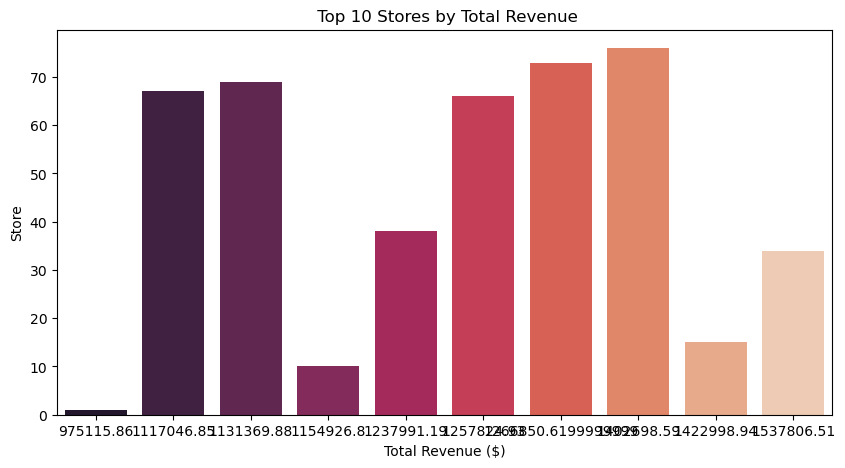

```python
top_stores = sales.groupby('Store')['Revenue'].sum().sort_values(ascending=False).head(10)

plt.figure(figsize=(10,5))
sns.barplot(x=top_stores.values, y=top_stores.index, palette='rocket')
plt.title(" Top 10 Stores by Total Revenue")
plt.xlabel("Total Revenue ($)")
plt.ylabel("Store")
plt.show()
```

```python
import pandas as pd
import matplotlib.pyplot as plt
import seaborn as sns

# adjust the path to where the CSV actually lives
base_path = "/Users/Teens/Desktop/challenge"

sales = pd.read_csv(f"{base_path}/SalesFINAL12312016.csv")
```

```python
sales.head(2)
```

|  | InventoryId | Store | Brand | Description | Size | SalesQuantity | SalesDollars | SalesPrice | SalesDate | Volume | Classification | ExciseTax | VendorNo | VendorName |
| --- | --- | --- | --- | --- | --- | --- | --- | --- | --- | --- | --- | --- | --- | --- |
| 0 | 1_HARDERSFIELD_1004 | 1 | 1004 | Jim Beam w/2 Rocks Glasses | 750mL | 1 | 16.49 | 16.49 | 1/1/2016 | 750 | 1 | 0.79 | 12546 | JIM BEAM BRANDS COMPANY |
| 1 | 1_HARDERSFIELD_1004 | 1 | 1004 | Jim Beam w/2 Rocks Glasses | 750mL | 2 | 32.98 | 16.49 | 1/2/2016 | 750 | 1 | 1.57 | 12546 | JIM BEAM BRANDS COMPANY |

```python
sales["Revenue"] = sales["SalesQuantity"] * sales["SalesPrice"]
sales.head(2)
```

|  | InventoryId | Store | Brand | Description | Size | SalesQuantity | SalesDollars | SalesPrice | SalesDate | Volume | Classification | ExciseTax | VendorNo | VendorName | Revenue |
| --- | --- | --- | --- | --- | --- | --- | --- | --- | --- | --- | --- | --- | --- | --- | --- |
| 0 | 1_HARDERSFIELD_1004 | 1 | 1004 | Jim Beam w/2 Rocks Glasses | 750mL | 1 | 16.49 | 16.49 | 1/1/2016 | 750 | 1 | 0.79 | 12546 | JIM BEAM BRANDS COMPANY | 16.49 |
| 1 | 1_HARDERSFIELD_1004 | 1 | 1004 | Jim Beam w/2 Rocks Glasses | 750mL | 2 | 32.98 | 16.49 | 1/2/2016 | 750 | 1 | 1.57 | 12546 | JIM BEAM BRANDS COMPANY | 32.98 |

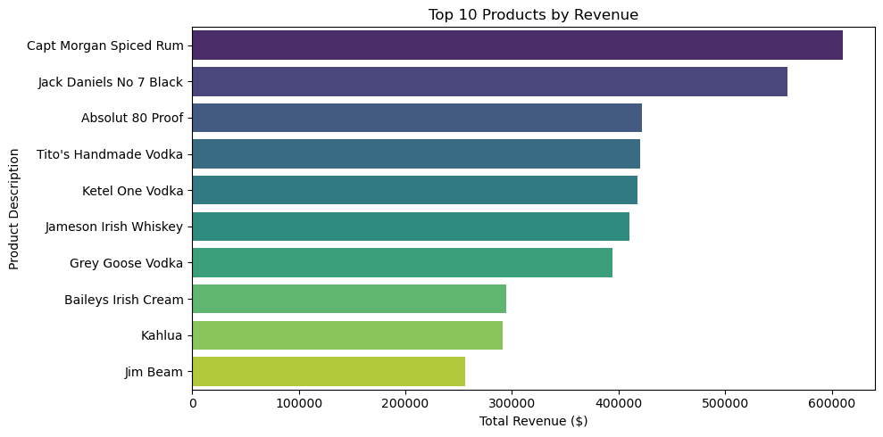

```python
top_products = (
    sales.groupby("Description")["Revenue"]
    .sum()
    .sort_values(ascending=False)
    .head(10)
)

plt.figure(figsize=(10, 5))
sns.barplot(
    x=top_products.values,
    y=top_products.index,
    hue=top_products.index,   # fixes FutureWarning
    palette="viridis",
    legend=False,
)
plt.title("Top 10 Products by Revenue")
plt.xlabel("Total Revenue ($)")
plt.ylabel("Product Description")
plt.tight_layout()
plt.show()
```

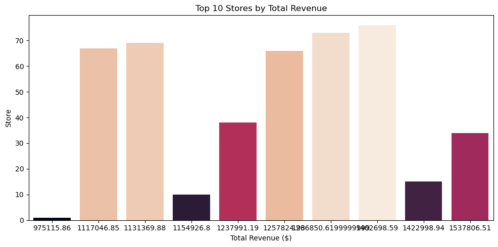

```python
# Group data by Store, sum the total Revenue for each store, and get the top 10
top_stores = (
    sales.groupby("Store")["Revenue"]
    .sum()
    .sort_values(ascending=False)
    .head(10)
)

# Plot Top 10 Stores by Total Revenue
plt.figure(figsize=(10,5))
sns.barplot(
    x=top_stores.values,
    y=top_stores.index,
    hue=top_stores.index,
    palette='rocket',
    legend=False
)
plt.title("Top 10 Stores by Total Revenue")
plt.xlabel("Total Revenue ($)")
plt.ylabel("Store")
plt.tight_layout()
plt.show()
```

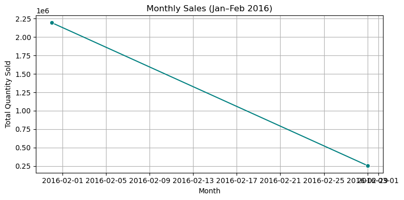

|  | SalesDate | SalesQuantity | Forecast |
| --- | --- | --- | --- |
| 0 | 2016-01-31 | 2194959 | NaN |
| 1 | 2016-02-29 | 256210 | NaN |

```python
# SalesDate to datetime type
sales["SalesDate"] = pd.to_datetime(sales["SalesDate"], errors="coerce")

monthly_sales = (
    sales.groupby(pd.Grouper(key="SalesDate", freq="ME"))["SalesQuantity"]
    .sum()
    .reset_index()
)

# monthly sales trend
plt.figure(figsize=(8,4))
sns.lineplot(data=monthly_sales, x="SalesDate", y="SalesQuantity", marker="o", color="teal")
plt.title("Monthly Sales (Jan–Feb 2016)")
plt.xlabel("Month")
plt.ylabel("Total Quantity Sold")
plt.grid(True)
plt.tight_layout()
plt.show()

monthly_sales["Forecast"] = monthly_sales["SalesQuantity"].rolling(window=3).mean()
monthly_sales.tail()
```

```python
# Group total revenue for each product
total_revenue = (
    sales.groupby("Description")["Revenue"]
    .sum()
    .sort_values(ascending=False)
)

# Calculate cumulative percentage
cum_percent = 100 * total_revenue.cumsum() / total_revenue.sum()

# ABC DataFrame
abc_df = pd.DataFrame({
    "Revenue": total_revenue,
    "Cumulative%": cum_percent
})

# Classify products to A/B/C categories
abc_df["Category"] = pd.cut(
    cum_percent,
    bins=[0, 80, 95, 100],   # A = top 80%, B = next 15%, C = last 5%
    labels=["A", "B", "C"]
)

# count of each category
abc_df["Category"].value_counts()
```

```
Category
C    4091
B    1673
A    1126
Name: count, dtype: int64
```

```python
# product per category
for cat in ["A", "B", "C"]:
    print(f"\nTop 5 products in Category {cat}:")
    display(abc_df[abc_df["Category"] == cat].head(5))
```

```
Top 5 products in Category A:
```

| Description | Revenue | Cumulative% | Category |
| --- | --- | --- | --- |
| Capt Morgan Spiced Rum | 610008.34 | 1.840736 | A |
| Jack Daniels No 7 Black | 558064.03 | 3.524727 | A |
| Absolut 80 Proof | 422095.29 | 4.798424 | A |
| Tito's Handmade Vodka | 420186.25 | 6.066360 | A |
| Ketel One Vodka | 417950.59 | 7.327551 | A |

```
Top 5 products in Category B:
```

| Description | Revenue | Cumulative% | Category |
| --- | --- | --- | --- |
| Steele Chard Cal | 5716.44 | 80.016821 | B |
| De Loach Chard Cal | 5704.29 | 80.034034 | B |
| Alderbrook Pnt Nr RRV | 5702.83 | 80.051243 | B |
| Smirnoff Whipped Cream | 5700.41 | 80.068444 | B |
| Jim Beam Choice | 5690.18 | 80.085614 | B |

```
Top 5 products in Category C:
```

| Description | Revenue | Cumulative% | Category |
| --- | --- | --- | --- |
| LaLuca Prosecco | 1402.83 | 95.000482 | C |
| Farnum Hill Farmhouse Cider | 1402.44 | 95.004714 | C |
| Opici Fish Bottle Bianco | 1401.83 | 95.008944 | C |
| Covey Run Rsl Columbia Vly | 1401.66 | 95.013174 | C |
| Glenfiddich The Original | 1399.86 | 95.017398 | C |

```python
A_items = abc_df[abc_df["Category"] == "A"]
B_items = abc_df[abc_df["Category"] == "B"]
C_items = abc_df[abc_df["Category"] == "C"]

# top 10 A-class high value items
A_items.sort_values("Revenue", ascending=False).head(10)
```

| Description | Revenue | Cumulative% | Category |
| --- | --- | --- | --- |
| Capt Morgan Spiced Rum | 610008.34 | 1.840736 | A |
| Jack Daniels No 7 Black | 558064.03 | 3.524727 | A |
| Absolut 80 Proof | 422095.29 | 4.798424 | A |
| Tito's Handmade Vodka | 420186.25 | 6.066360 | A |
| Ketel One Vodka | 417950.59 | 7.327551 | A |
| Jameson Irish Whiskey | 410287.84 | 8.565618 | A |
| Grey Goose Vodka | 394280.19 | 9.755382 | A |
| Baileys Irish Cream | 294738.43 | 10.644772 | A |
| Kahlua | 290933.11 | 11.522680 | A |
| Jim Beam | 255837.61 | 12.294685 | A |

```python
import numpy as np

# EOQ = sqrt( (2 * D * S) / H )
# D = annual demand (total quantity sold)
# S = ordering cost per order (assumed or estimated)
# H = holding cost per unit per year (assumed or estimated)

D = sales["SalesQuantity"].sum()
S = 50
H = 2

EOQ = np.sqrt((2 * D * S) / H)

print(" EOQ (Optimal Order Quantity):", round(EOQ, 2), "units")
```

```
 EOQ (Optimal Order Quantity): 11070.61 units
```

```python
print("Purchases columns:\n", purchases.columns.tolist())
```

```
Purchases columns:
 ['InventoryId', 'Store', 'Brand', 'Description', 'Size', 'VendorNumber', 'VendorName', 'PONumber', 'PODate', 'ReceivingDate', 'InvoiceDate', 'PayDate', 'PurchasePrice', 'Quantity', 'Dollars', 'Classification']
```

```python
# Convert relevant date columns to datetime
purchases["PODate"] = pd.to_datetime(purchases["PODate"], errors="coerce")
purchases["ReceivingDate"] = pd.to_datetime(purchases["ReceivingDate"], errors="coerce")

# Calculate Lead Time in days
purchases["LeadTime_Days"] = (purchases["ReceivingDate"] - purchases["PODate"]).dt.days

# Filter out any unrealistic or missing lead times
purchases = purchases[purchases["LeadTime_Days"].between(0, 60)]  # assuming typical range within 2 months

# Compute average and standard deviation of lead time
avg_lead_time = purchases["LeadTime_Days"].mean()
std_lead_time = purchases["LeadTime_Days"].std()

# Compute average daily demand from Sales
daily_demand = sales["SalesQuantity"].sum() / 365

# Safety stock (for 95% service level, z = 1.65)
z = 1.65
safety_stock = z * std_lead_time * (daily_demand ** 0.5)

# Reorder Point (ROP)
ROP = (daily_demand * avg_lead_time) + safety_stock

print(f"Average Lead Time: {avg_lead_time:.2f} days")
print(f"  Safety Stock: {round(safety_stock)} units")
print(f" Reorder Point (ROP): {round(ROP)} units")
```

```
Average Lead Time: 7.62 days
  Safety Stock: 299 units
 Reorder Point (ROP): 51476 units
```

```python
# Group by VendorName to measure efficiency
supplier_lead = (
    purchases.groupby("VendorName")["LeadTime_Days"]
    .agg(["mean", "std", "count"])
    .reset_index()
    .sort_values("mean")
)

# Display top 10 fastest suppliers
print(" Fastest 10 Suppliers (Lowest Average Lead Time):")
display(supplier_lead.head(10))

# Display slowest 10 suppliers
print("\nSlowest 10 Suppliers (Highest Average Lead Time):")
display(supplier_lead.tail(10))
```

```
 Fastest 10 Suppliers (Lowest Average Lead Time):
```

|  | VendorName | mean | std | count |
| --- | --- | --- | --- | --- |
| 113 | TRUETT HURST | 5.000000 | NaN | 1 |
| 45 | HIGHLAND WINE MERCHANTS LLC | 5.321429 | 2.178235 | 28 |
| 57 | LOYAL DOG WINERY | 5.950000 | 2.438183 | 20 |
| 64 | MARTIGNETTI COMPANIES | 6.697279 | 1.972557 | 294 |
| 2 | ALISA CARR BEVERAGES | 6.809524 | 2.723003 | 63 |
| 25 | Circa Wines | 6.948498 | 1.977658 | 233 |
| 76 | PHILLIPS PRODUCTS CO. | 7.012447 | 2.109132 | 4981 |
| 89 | SEA HAGG DISTILLERY LLC | 7.022823 | 2.038210 | 1183 |
| 70 | NICHE W & S | 7.069797 | 2.350258 | 788 |
| 69 | MOONLIGHT MEADERY | 7.083700 | 2.478208 | 681 |

```
Slowest 10 Suppliers (Highest Average Lead Time):
```

|  | VendorName | mean | std | count |
| --- | --- | --- | --- | --- |
| 115 | ULTRA BEVERAGE COMPANY LLP | 8.410477 | 2.033624 | 84034 |
| 97 | STARK BREWING COMPANY | 8.487805 | 2.134502 | 41 |
| 92 | SILVER MOUNTAIN CIDERS | 8.500000 | 0.707107 | 2 |
| 123 | WALPOLE MTN VIEW WINERY | 8.527027 | 2.394188 | 74 |
| 117 | VINEDREA WINES LLC | 8.818182 | 2.007090 | 33 |
| 10 | BLACK COVE BEVERAGES | 9.318182 | 2.164972 | 44 |
| 48 | IRA GOLDMAN AND WILLIAMS, LLP | 9.615385 | 1.043908 | 13 |
| 56 | LAUREATE IMPORTS CO | 10.000000 | NaN | 1 |
| 0 | AAPER ALCOHOL & CHEMICAL CO | 10.000000 | NaN | 1 |
| 38 | FLAVOR ESSENCE INC | 13.000000 | NaN | 1 |

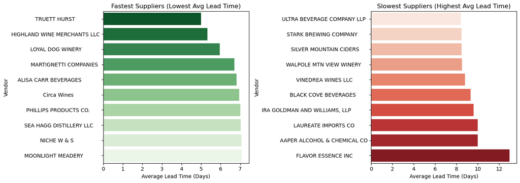

```python
# pick the top 10 fastest and slowest for comparison
fastest = supplier_lead.head(10)
slowest = supplier_lead.tail(10)

fig, ax = plt.subplots(1, 2, figsize=(14,5))

# Fastest suppliers
sns.barplot(x="mean", y="VendorName", data=fastest, palette="Greens_r", ax=ax[0])
ax[0].set_title("Fastest Suppliers (Lowest Avg Lead Time)")
ax[0].set_xlabel("Average Lead Time (Days)")
ax[0].set_ylabel("Vendor")

# Slowest suppliers
sns.barplot(x="mean", y="VendorName", data=slowest, palette="Reds", ax=ax[1])
ax[1].set_title("Slowest Suppliers (Highest Avg Lead Time)")
ax[1].set_xlabel("Average Lead Time (Days)")
ax[1].set_ylabel("Vendor")

plt.tight_layout()
plt.show()
```

```python
print("Begin Inventory Columns:\n", begin_inventory.columns.tolist())
print("\nEnd Inventory Columns:\n", end_inventory.columns.tolist())
```

```
Begin Inventory Columns:
 ['InventoryId', 'Store', 'City', 'Brand', 'Description', 'Size', 'onHand', 'Price', 'startDate']

End Inventory Columns:
 ['InventoryId', 'Store', 'City', 'Brand', 'Description', 'Size', 'onHand', 'Price', 'endDate']
```

```python
# Merge beginning and ending inventories using common identifiers
merged_inv = begin_inventory.merge(
    end_inventory,
    on=["InventoryId", "Store", "Brand", "Description"],
    suffixes=("_Beg", "_End")
)

# Ensure the stock numbers are numeric
merged_inv["onHand_Beg"] = pd.to_numeric(merged_inv["onHand_Beg"], errors="coerce")
merged_inv["onHand_End"] = pd.to_numeric(merged_inv["onHand_End"], errors="coerce")

# Calculate change in stock
merged_inv["ChangeInStock"] = merged_inv["onHand_End"] - merged_inv["onHand_Beg"]

# Fast-moving (stock dropped) and slow-moving (stock rose) items
fast_movers = merged_inv.sort_values("ChangeInStock").head(10)
slow_movers = merged_inv.sort_values("ChangeInStock", ascending=False).head(10)

print(" Fast-Moving Products (Largest Stock Decrease):")
display(fast_movers[["InventoryId","Brand","Description","onHand_Beg","onHand_End","ChangeInStock"]])

print("\n Slow-Moving / Overstocked Products (Largest Stock Increase):")
display(slow_movers[["InventoryId","Brand","Description","onHand_Beg","onHand_End","ChangeInStock"]])
```

```
 Fast-Moving Products (Largest Stock Decrease):
```

|  | InventoryId | Brand | Description | onHand_Beg | onHand_End | ChangeInStock |
| --- | --- | --- | --- | --- | --- | --- |
| 67069 | 34_PITMERDEN_3876 | 3876 | Smirnoff 80 Proof | 930 | 107 | -823 |
| 170120 | 79_BALLYMENA_3859 | 3859 | Smirnoff 80 Proof | 1163 | 351 | -812 |
| 132420 | 65_LUTON_7341 | 7341 | Smirnoff Watermelon | 921 | 144 | -777 |
| 67064 | 34_PITMERDEN_3858 | 3858 | Grey Goose Vodka | 818 | 88 | -730 |
| 144305 | 69_MOUNTMEND_3858 | 3858 | Grey Goose Vodka | 1251 | 527 | -724 |
| 133776 | 66_EANVERNESS_3876 | 3876 | Smirnoff 80 Proof | 597 | 25 | -572 |
| 163070 | 76_DONCASTER_3876 | 3876 | Smirnoff 80 Proof | 541 | 19 | -522 |
| 77019 | 38_GOULCREST_6570 | 6570 | Kendall Jackson Chard Vt RSV | 706 | 184 | -522 |
| 66660 | 34_PITMERDEN_2663 | 2663 | Dewars White Label | 576 | 93 | -483 |
| 67806 | 34_PITMERDEN_8082 | 8082 | Baileys Irish Cream | 503 | 35 | -468 |

```
 Slow-Moving / Overstocked Products (Largest Stock Increase):
```

|  | InventoryId | Brand | Description | onHand_Beg | onHand_End | ChangeInStock |
| --- | --- | --- | --- | --- | --- | --- |
| 137781 | 67_EANVERNESS_5111 | 5111 | Dr McGillicuddy's Mentholmnt | 164 | 3005 | 2841 |
| 99148 | 50_MOUNTMEND_3102 | 3102 | Smirnoff Traveler | 300 | 1227 | 927 |
| 42105 | 22_SHARNWICK_1892 | 1892 | Yukon Jack | 140 | 1038 | 898 |
| 52441 | 27_MOUNTMEND_126 | 126 | Grey Goose Vodka | 15 | 884 | 869 |
| 159584 | 74_PAENTMARWY_8184 | 8184 | Kahlua | 41 | 872 | 831 |
| 99224 | 50_MOUNTMEND_3405 | 3405 | Tito's Handmade Vodka | 339 | 1164 | 825 |
| 159321 | 74_PAENTMARWY_5708 | 5708 | Dr McGillicuddy's Root Beer | 0 | 715 | 715 |
| 98710 | 50_MOUNTMEND_1233 | 1233 | Jack Daniels No 7 Black | 537 | 1246 | 709 |
| 28245 | 15_WANBORNE_126 | 126 | Grey Goose Vodka | 104 | 787 | 683 |
| 100090 | 50_MOUNTMEND_8068 | 8068 | Absolut 80 Proof | 601 | 1273 | 672 |

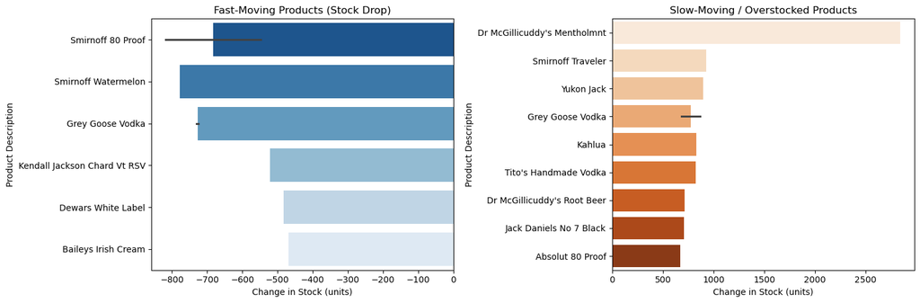

```python
# Take top 10 fastest movers and slowest movers from previous cell
top_fast = fast_movers.sort_values("ChangeInStock").head(10)
top_slow = slow_movers.sort_values("ChangeInStock", ascending=False).head(10)

# Create side-by-side plots
fig, ax = plt.subplots(1, 2, figsize=(15,5))

# Fast-Moving Items (stock decreased)
sns.barplot(
    x="ChangeInStock",
    y="Description",
    data=top_fast,
    palette="Blues_r",
    ax=ax[0]
)
ax[0].set_title("Fast-Moving Products (Stock Drop)")
ax[0].set_xlabel("Change in Stock (units)")
ax[0].set_ylabel("Product Description")

# Slow-Moving / Overstocked Items (stock increased)
sns.barplot(
    x="ChangeInStock",
    y="Description",
    data=top_slow,
    palette="Oranges",
    ax=ax[1]
)
ax[1].set_title("Slow-Moving / Overstocked Products")
ax[1].set_xlabel("Change in Stock (units)")
ax[1].set_ylabel("Product Description")

plt.tight_layout()
plt.show()
```

```python
# Ensure purchase_prices is loaded (if not already)
# purchase_prices = pd.read_csv(f"{base_path}/2017PurchasePricesDec.csv")

# Clean column names for consistency
purchase_prices.columns = purchase_prices.columns.str.strip().str.title()

# Check basic info
purchase_prices.head(2)
```

|  | Brand | Description | Price | Size | Volume | Classification | Purchaseprice | Vendornumber | Vendorname |
| --- | --- | --- | --- | --- | --- | --- | --- | --- | --- |
| 0 | 58 | Gekkeikan Black & Gold Sake | 12.99 | 750mL | 750 | 1 | 9.28 | 8320 | SHAW ROSS INT L IMP LTD |
| 1 | 62 | Herradura Silver Tequila | 36.99 | 750mL | 750 | 1 | 28.67 | 1128 | BROWN-FORMAN CORP |

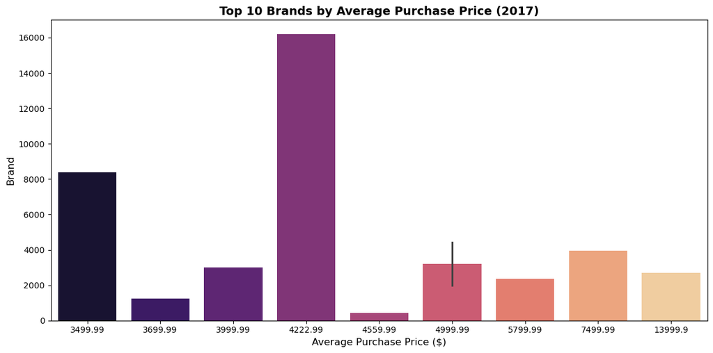

```python
# Group by Brand and calculate average purchase price
brand_prices = (
    purchase_prices.groupby("Brand")["Price"]
    .mean()
    .sort_values(ascending=False)
    .reset_index()
)

# Plot Top 10 Brands with visible labels
plt.figure(figsize=(12,6))
sns.barplot(
    data=brand_prices.head(10),
    x="Price",
    y="Brand",
    palette="magma"
)
plt.title("Top 10 Brands by Average Purchase Price (2017)", fontsize=14, weight="bold")
plt.xlabel("Average Purchase Price ($)", fontsize=12)
plt.ylabel("Brand", fontsize=12)

# Make sure labels are fully visible and formatted
plt.xticks(fontsize=10)
plt.yticks(fontsize=10)
plt.tight_layout()
plt.show()
```

```python
print(f"""
FINAL SUMMARY REPORT — SLOOZE INVENTORY ANALYSIS

 SALES OVERVIEW
• Total Transactions: {len(sales):,}
• Total Revenue: ${sales['Revenue'].sum():,.2f}
• Highest Revenue Product: {sales.groupby('Description')['Revenue'].sum().idxmax()}
• Top Performing Store: {sales.groupby('Store')['Revenue'].sum().idxmax()}

 INVENTORY INSIGHTS
• A-Class Products (High Value): {(abc_df['Category'] == 'A').sum():,}
• B-Class Products (Medium Value): {(abc_df['Category'] == 'B').sum():,}
• C-Class Products (Low Value): {(abc_df['Category'] == 'C').sum():,}
• EOQ (Optimal Order Quantity): {EOQ:,.2f} units
• Reorder Point (ROP): {ROP:,.2f} units
• Average Lead Time: {avg_lead_time:.2f} days

 SUPPLIER PERFORMANCE
• Fastest Supplier: {supplier_lead.iloc[0]['VendorName']} ({supplier_lead.iloc[0]['mean']:.2f} days)
• Slowest Supplier: {supplier_lead.iloc[-1]['VendorName']} ({supplier_lead.iloc[-1]['mean']:.2f} days)

 INVENTORY MOVEMENT
• Fastest Moving Product: {fast_movers.iloc[0]['Description']}
• Slowest Moving Product: {slow_movers.iloc[0]['Description']}

 PURCHASE PRICE ANALYSIS
• Most Expensive Brand (avg): {brand_prices.iloc[0]['Brand']} (${brand_prices.iloc[0]['Price']:.2f})
• Least Expensive Brand (avg): {brand_prices.iloc[-1]['Brand']} (${brand_prices.iloc[-1]['Price']:.2f})

 INSIGHTS SUMMARY
1. Focus inventory control on A-class items — they drive most revenue.
2. Maintain ~{round(ROP)} units reorder level to prevent stockouts.
3. Negotiate better terms with slower suppliers (> {round(supplier_lead.iloc[-1]['mean'])} days lead time).
4. Review slow-moving and high-cost brands for discount or delisting.
5. EOQ ≈ {round(EOQ)} units ensures balanced ordering and holding costs.
""")
```

```
FINAL SUMMARY REPORT — SLOOZE INVENTORY ANALYSIS

 SALES OVERVIEW
• Total Transactions: 1,048,575
• Total Revenue: $33,139,375.29
• Highest Revenue Product: Capt Morgan Spiced Rum
• Top Performing Store: 34

 INVENTORY INSIGHTS
• A-Class Products (High Value): 1,126
• B-Class Products (Medium Value): 1,673
• C-Class Products (Low Value): 4,091
• EOQ (Optimal Order Quantity): 11,070.61 units
• Reorder Point (ROP): 51,475.99 units
• Average Lead Time: 7.62 days

 SUPPLIER PERFORMANCE
• Fastest Supplier: TRUETT HURST                (5.00 days)
• Slowest Supplier: FLAVOR ESSENCE INC          (13.00 days)

 INVENTORY MOVEMENT
• Fastest Moving Product: Smirnoff 80 Proof
• Slowest Moving Product: Dr McGillicuddy's Mentholmnt

 PURCHASE PRICE ANALYSIS
• Most Expensive Brand (avg): 2693.0 ($13999.90)
• Least Expensive Brand (avg): 4202.0 ($0.00)

 INSIGHTS SUMMARY
1. Focus inventory control on A-class items — they drive most revenue.
2. Maintain ~51476 units reorder level to prevent stockouts.
3. Negotiate better terms with slower suppliers (> 13 days lead time).
4. Review slow-moving and high-cost brands for discount or delisting.
5. EOQ ≈ 11071 units ensures balanced ordering and holding costs.
```